# Projekt 2

Celem projektu jest przetestowanie paru algorytmów klasyfikujących na wybranym zbiorze danych.

Dane, które wybrałam to "Credit score classification" - baza ta jest numeryczno-kategoryczną, zawiera podstawowe dane bankowe i gromadzi wiele informacji związanych z kredytami. W czterech poniżej zaprezentowanych algorytmach będziemy przewidywać ocenę kredytową - przypisaną kolumnie "Credit_Score" (Poor, Standard, Good).

Baza danych składa się z 28 kolumn i 100000 wierszy. Po załadowaniu jej do jupytera zaczęłam od przygotowania zbioru danych przygotowania zbioru danych do treningu modelu - klasyfikacji.

# Preprocessing bazy danych

Wybrana przeze mnie baza ma niestety dużo błędów oraz brakujących danych.

Poniżej w tabeli widać ile każda kolumna zawiera pustych wartości:

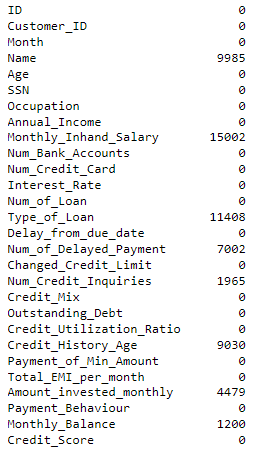

Pracę nad bazą danych zaczęłam od usunięcia 3 kolumn - ID, Name oraz SSN (numer ubezpieczenia społecznego danej osoby), które uznałam za nieprzydatne i zbędne w dalszej pracy.

Niektóre zmienne na przykład Num_Bank_Accounts (liczba rachunków bankowych posiadanych przez osobę) zawierały wartości ujemne co też należało poprawić.

```python
def fill_null_values(dane):
    data_copy = dane.copy()

    # identyfikujemy kolumny z wartościami null
    null_cols = data_copy.columns[data_copy.isna().any()]

    for col in null_cols:
        # Sprawdzamy czy kolumna jest kategoryczna czy numeryczna
        if data_copy[col].dtype in ['int64', 'float64']:
            # null values zamieniamy na mediane
            data_copy[col].fillna(data_copy[col].median(), inplace=True)
        else:
            # null values zamieniamy na najpopularniejszy wyraz
            data_copy[col].fillna(data_copy[col].mode()[0], inplace=True)

    return data_copy
```

Błędy strukturalne - nieprawidłowe dane w kolumnie zamieniamy z poprawnymi wartościami

```python
dane = dane.applymap(lambda x: x if x is np.NaN or not \
        isinstance(x, str) else str(x).strip('_')).replace(['','nan', '!@9#%8', '#F%$D@*&8'], np.NaN)

# Credit History Age ma lata i miesiące połączone jako wartość np. "22 years and 1 month".
def take_years(x):  # Będziemy brać tylko lata
    if x is not None:
        return str(x).strip()[0:2]

dane.Credit_History_Age = dane.Credit_History_Age.apply(take_years)
dane['Credit_History_Age'] = dane['Credit_History_Age'].replace({'na': np.NaN})
```

Poniżej tworzymy funkcję pomocniczą, która zwraca nam tabelkę z pomocnymi danymi do oceny jakości naszej bazy danych i tego czy baza jest gotowa do rozpoczęcia klasyfikacji.

```python
def tabela(dane):
    tabela = []
    columns = dane.columns
    for col in columns:
        dtype = dane[col].dtypes
        nunique = dane[col].nunique()
        null = dane[col].isnull().sum()
        duplicates = dane[col].duplicated().sum()
        tabela.append([col,dtype,nunique,null,duplicates])
    tabela_dane = pd.DataFrame(tabela)
    tabela_dane.columns = ['column','dtype','nunique','null','duplicates']
    return tabela_dane
```

Tak prezentuje się z początku wynik naszej funckji ( po niewielu obróbkach danych ):

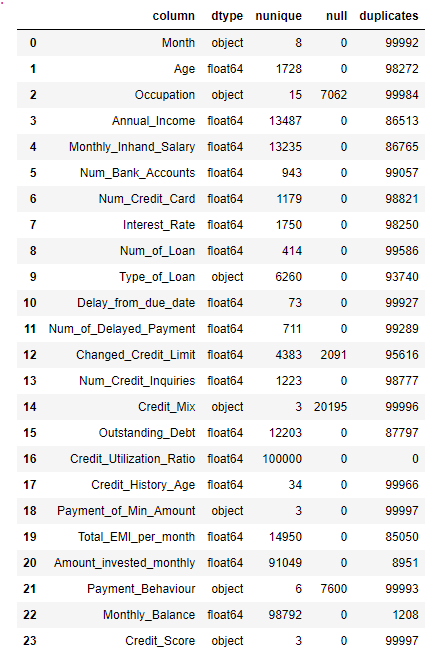

Następnie usuwamy odstające obserwacje korzystając z metody IQR.

```python
def usuwanie_odstajacych_danych(dane):
    data_copy = dane.copy()
    # Kolumny liczbowe
    num_cols = data_copy.select_dtypes(include=['float64', 'int64']).columns

    # Liczymy liczbę wartości odstających przed ich usunięciem
    num_outliers = 0
    for col in num_cols:
        q1 = data_copy[col].quantile(0.25)
        q3 = data_copy[col].quantile(0.75)
        x = q3 - q1
        lower_bound = q1 - (1.5 * x)
        upper_bound = q3 + (1.5 * x)
        num_outliers += len(data_copy[(data_copy[col] < lower_bound) | (data_copy[col] > upper_bound)])
    print("Liczba odstających obserwacji przed usuwaniem: ", num_outliers)

    for col in num_cols:
        # Calculate lower and upper bounds using the interquartile range (IQR) method
        q1 = data_copy[col].quantile(0.25)
        q3 = data_copy[col].quantile(0.75)
        x = q3 - q1
        lower_bound = q1 - (1.5 * x)
        upper_bound = q3 + (1.5 * x)

        # Usuń obserwacje poza granicami
        data_copy = data_copy[(data_copy[col] >= lower_bound) & (data_copy[col] <= upper_bound)]

    # Liczymy liczbę wartości odstających po ich usunięciu
    num_outliers = 0
    for col in num_cols:
        q1 = data_copy[col].quantile(0.25)
        q3 = data_copy[col].quantile(0.75)
        x = q3 - q1
        lower_bound = q1 - (1.5 * x)
        upper_bound = q3 + (1.5 * x)
        num_outliers += len(data_copy[(data_copy[col] < lower_bound) | (data_copy[col] > upper_bound)])
    print("Liczba odstających obserwacji po usuwaniu: ", num_outliers)

    return data_copy
```

Jak widać usuwamy ponac 40 tysięcy obserwacji.

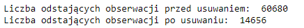

W kolumnie wieku ankietowanej osoby występowało wiele odpowiedzi niepoprawnych na przykład -500, 8350 z tego powodu zostawiamy tylko te dane, w których wiek ankietowanych zawiera się w przedziale 0 - 100.

```python
def usuwanie_odstajacych_danych(dane):
    data_copy = dane.copy()

    # Kolumna wieku
    age_col = data_copy['Age']

    # Usuń obserwacje z wiekiem mniejszym niż 0 lub większym niż 100
    data_copy = data_copy[(age_col >= 0) & (age_col <= 100)]

    return data_copy
```

```python
def fill_null_values(dane):

    data_copy = dane.copy()

    # Pobierz kolumny kategoryczne
    cat_cols = data_copy.select_dtypes(include=['object']).columns

    for col in cat_cols:
        # Najczęstsza wartość
        most_frequent = data_copy[col].mode()[0]

        # Zamień wartości „NaN” na najczęstszą wartość
        data_copy[col].fillna(most_frequent, inplace=True)

    return data_copy
```

Po przetworzeniu danych korzystamy z naszej pomocniczej funckcji 'tabelka' i możemy zauważyć że teraz nie ma żadnej wartości null w naszych danych.

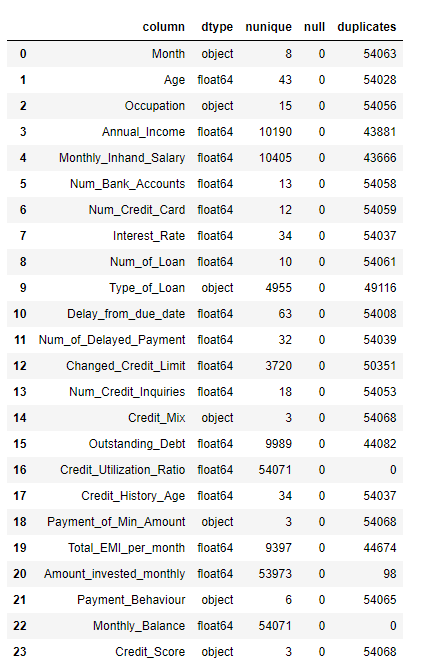

Kolejnym krokiem jest spojrzenie na korelacje i ocena, które kolumny warto brać pod uwagę podczas klasyfikacji, korzystając z biblioteki dython robimy heat-mapę wszytskich korelacji.

Poniżej znajduje się tylko jej wycinek, który będzie nam najbardziej potrzebny do oceny zależności między zmiennymi a zmienną 'Credit_Score'.

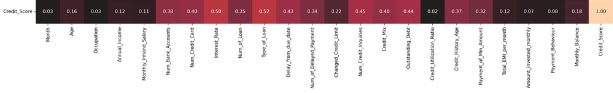

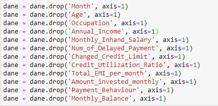

Następny etap to zamiana wszystkich kolumn kategorycznych na numeryczne. Mamy 4 kolumny kategoryczne, trzy z nich postanowiłam przekonwertować z tekstów na liczby. Każda wartość tekstowa dostaje inną liczbę. Kolumna pozostaje ta sama.

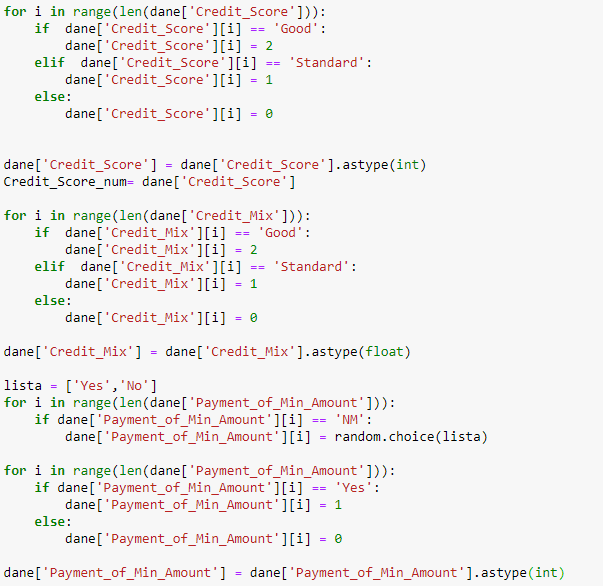

Czwartą kolumnę o nazwie 'Type_of_Loan' rozbiłam na kilka numerycznych o nagłówkach "Auto Loan", "Credit Builder Loan", 'Debt_consolidation_loan' itd. Jest tyle nowych kolumn ile typów pożyczek. W każdej z nowych kolumn pojawia się 0, gdy dana osoba nie ma tej pożyczki w kolumnie 'Type_of_Loan' lub 1, gdy ma tę pożyczkę.

Poniżej znajduje się kod w jaki sposób dokonałam tego rozbicia jednej kolumny na poszczególne.

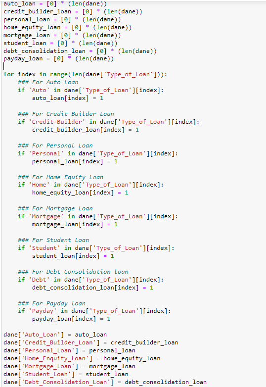

# Standaryzacja danych / skalowanie wartości wszystkich własności

Standaryzujemy nasze dane a następnie dodajemy do nich kolumnę 'Credit_Score'

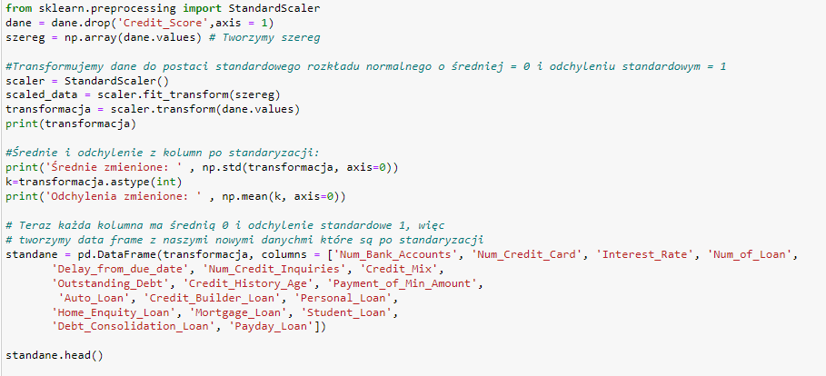

Na wystandaryzowanych danych przeprowadzamy analizę głównych składowych. Aby wiedzieć jaka liczba czynników w nowej przestrzeni będzie odpowiadać około 95% wariancji rysujemy wykres.

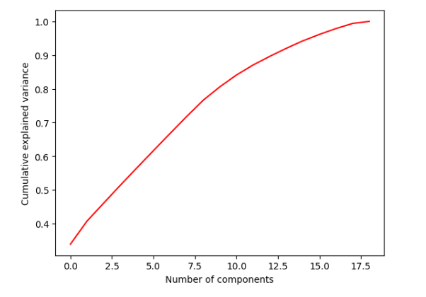

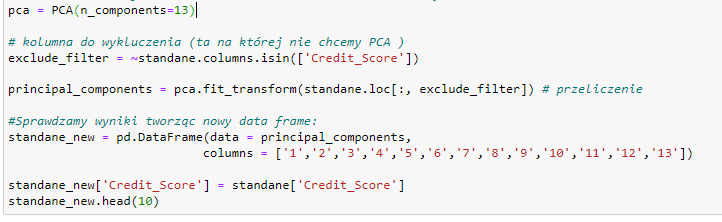

Zanim przejdziemy do klasyfikacji trzeba ustalić co oznaczają mniej i bardziej przetworzone dane w moim projekcie.

Dane mniej przetworzone to te, które nie są zmieniane oprócz preprocessingu, gdzie trzeba było wyeliminować odstające z próby wartości, lub zmienić zmienne kategoryczne na numeryczne.

Dane bardziej przetworzone są to dane po standaryzacji i po analizie metodą PCA.

# Klasyfikacja

Pierwszą rzeczą jaką trzeba zrobić to podzielić nasze dane na zbiory testujące i trenujące.

```python
(train_set1, test_set1) = train_test_split(standane_new.values, train_size=0.7,random_state=13)
#Generujemy zestaw uczący - do trenowania, który stanowi 70% naszych danych.
#Następnie użyjemy pozostałych danych do testowania - 30%.

train_inputs1 = train_set1[:, 0:13]
train_classes1 = train_set1[:, 13]
test_inputs1 = test_set1[:, 0:13]
test_classes1 = test_set1[:, 13]
```

# The k-Nearest Neighbors

k = 4

```python
knn = KNeighborsClassifier(n_neighbors = 4, metric='euclidean')
knn.fit(train_inputs, train_classes)

y_pred = knn.predict(test_inputs)

print("Accuracy:" , accuracy_score(test_classes, y_pred))


confusion_matrix = metrics.confusion_matrix(test_classes, y_pred)

cm_display = metrics.ConfusionMatrixDisplay(confusion_matrix = confusion_matrix)
cm_display = cm_display.plot(cmap=plt.cm.Blues,values_format='g')
```

Po prawej stronie mamy macierz błędów i dokładność algorytmu dla danych bardziej przetworzonych po lewej dla danych mniej przetworzonych, są one bardzo podobne do siebie.

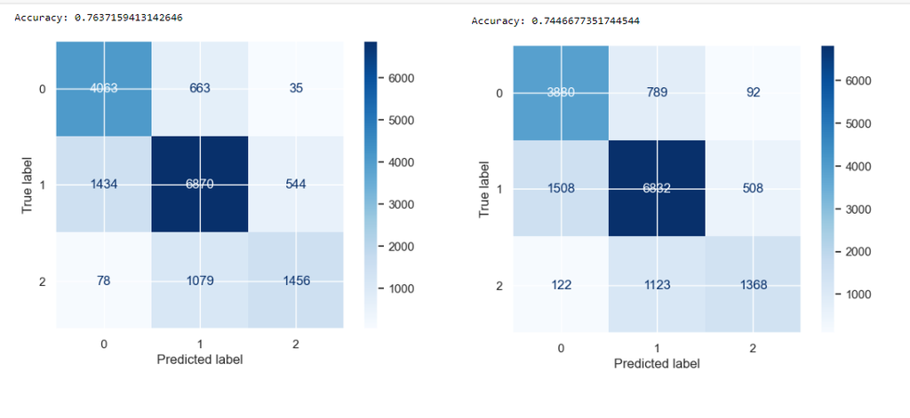

k = 6

```python
knn = KNeighborsClassifier(n_neighbors = 6, metric='euclidean')
knn.fit(train_inputs, train_classes)

y_pred = knn.predict(test_inputs)

print("Accuracy:" , accuracy_score(test_classes, y_pred))

confusion_matrix = metrics.confusion_matrix(test_classes, y_pred)
cm_display = metrics.ConfusionMatrixDisplay(confusion_matrix = confusion_matrix)
cm_display = cm_display.plot(cmap=plt.cm.Blues,values_format='g')
```

Ponownie po prawej stronie mamy macierz błędów i dokładność algorytmu dla danych bardziej przetworzonych po lewej dla danych mniej przetworzonych.

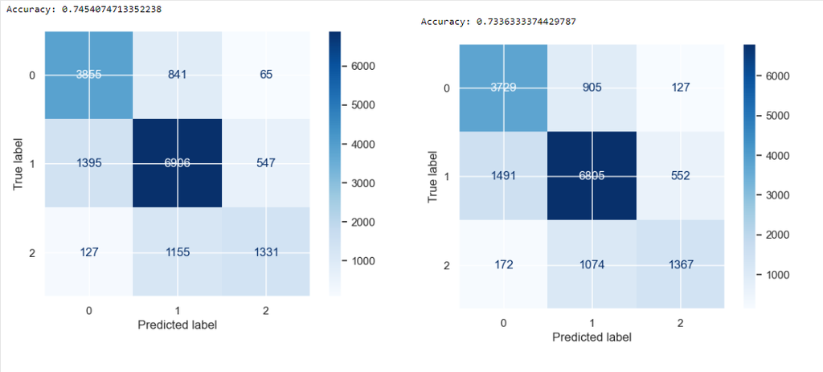

k = 10

```python
knn = KNeighborsClassifier(n_neighbors = 10, metric='euclidean')
knn.fit(train_inputs, train_classes)

y_pred = knn.predict(test_inputs)
print("Accuracy:" , accuracy_score(test_classes, y_pred))

confusion_matrix = metrics.confusion_matrix(test_classes, y_pred)

cm_display = metrics.ConfusionMatrixDisplay(confusion_matrix = confusion_matrix)
cm_display = cm_display.plot(cmap=plt.cm.Blues,values_format='g')
```

Ponownie po prawej stronie mamy macierz błędów i dokładność algorytmu dla danych bardziej przetworzonych po lewej dla danych mniej przetworzonych.

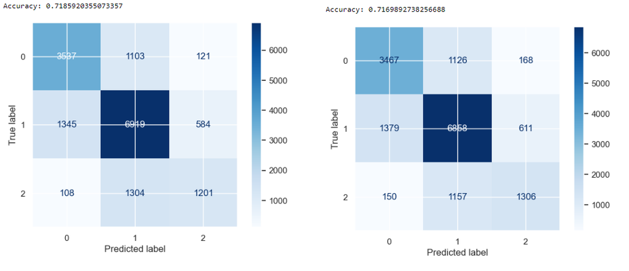

# Naive Bayes

```python
model = GaussianNB()
model.fit(train_inputs,train_classes)
y_pred = model.predict(test_inputs)
accuray = accuracy_score(y_pred, test_classes)
print("Accuracy:", accuray)

confusion_matrix = metrics.confusion_matrix(test_classes, y_pred)

cm_display = metrics.ConfusionMatrixDisplay(confusion_matrix = confusion_matrix)
cm_display = cm_display.plot(cmap=plt.cm.Greens,values_format='g')
```

Kod w obu przypadkach był taki sam jedyne co się zmieniło to wyniki, które znajdują się poniżej po prawej dla danych bardziej przetworzonych po lewej dla mniej.

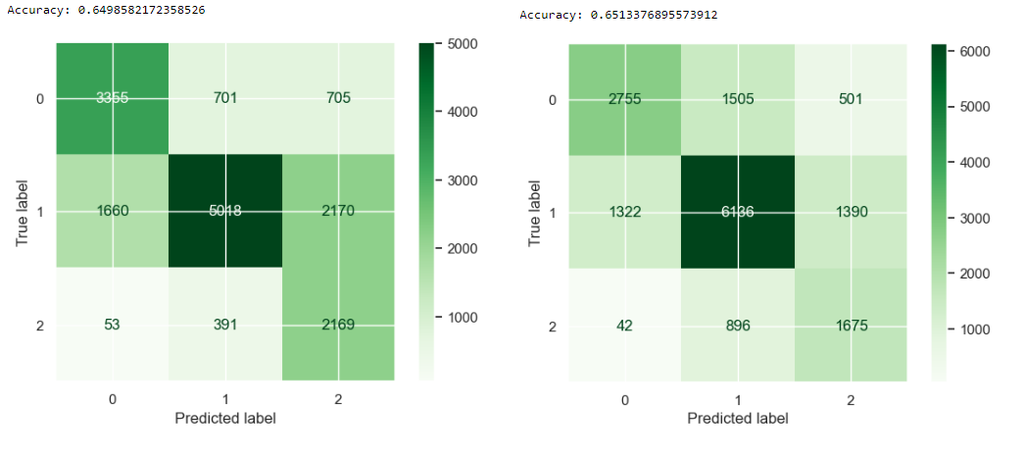

# Decision Tree Algorithm

Drzewo decyzyjne z dwiema gałęziami dla mniej przetowrzonych danych

```python
dtc = tree.DecisionTreeClassifier(max_depth = 2, criterion = 'entropy')
dtc = dtc.fit(train_inputs, train_classes)

y_pred = dtc.predict(test_inputs)

print("Accuracy:" , accuracy_score(test_classes, y_pred))
confusion_matrix = metrics.confusion_matrix(test_classes, y_pred)

cm_display = metrics.ConfusionMatrixDisplay(confusion_matrix = confusion_matrix)
cm_display = cm_display.plot(cmap=plt.cm.Purples,values_format='g')
```

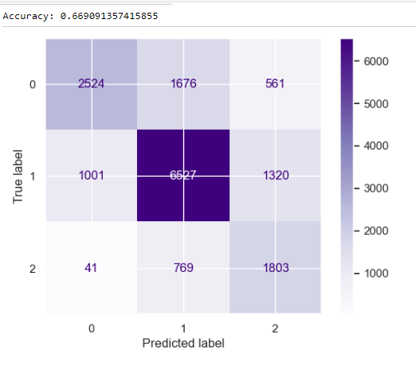

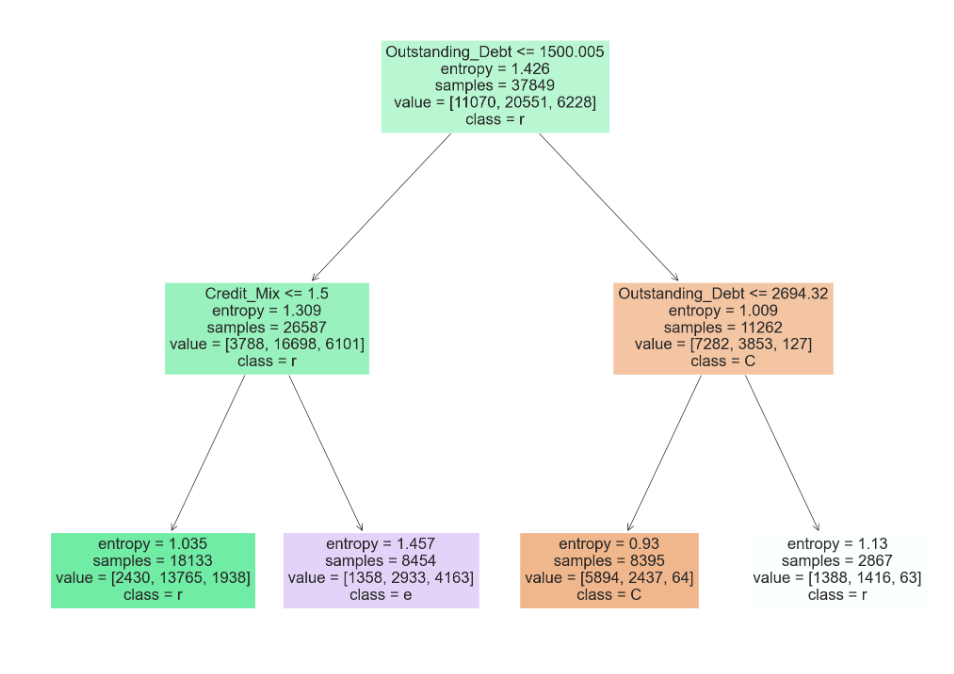

Drzewo decyzyjne - wersja większa dla mniej przetworzonych danych

```python
dtc = tree.DecisionTreeClassifier(max_depth = 15, criterion = 'entropy')
dtc = dtc.fit(train_inputs, train_classes)

y_pred = dtc.predict(test_inputs)

print("Accuracy:" , accuracy_score(test_classes, y_pred))

confusion_matrix = metrics.confusion_matrix(test_classes, y_pred)

cm_display = metrics.ConfusionMatrixDisplay(confusion_matrix = confusion_matrix)
cm_display = cm_display.plot(cmap=plt.cm.Purples,values_format='g')
```

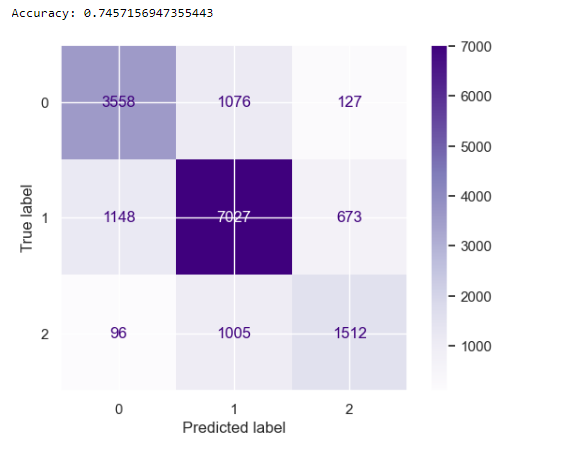

Drzewo decyzyjne z dwiema gałęziami dla bardziej przetowrzonych danych

```python
dtc = tree.DecisionTreeClassifier(max_depth = 2, criterion = 'entropy')
dtc = dtc.fit(train_inputs1, train_classes1)

y_pred1 = dtc.predict(test_inputs1)

print("Accuracy:" , accuracy_score(test_classes1, y_pred1))
confusion_matrix = metrics.confusion_matrix(test_classes1, y_pred1)

cm_display = metrics.ConfusionMatrixDisplay(confusion_matrix = confusion_matrix)
cm_display = cm_display.plot(cmap=plt.cm.Purples,values_format='g')
```

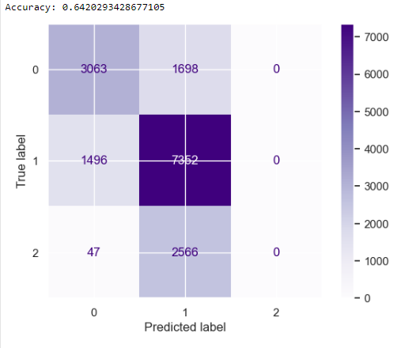

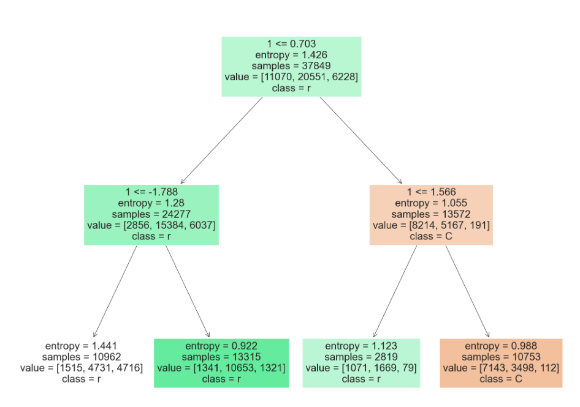

Drzewo decyzyjne - wersja większa dla bardziej przetworzonych danych

```python
dtc = tree.DecisionTreeClassifier(max_depth = 12, criterion = 'entropy')
dtc = dtc.fit(train_inputs1, train_classes1)

y_pred1 = dtc.predict(test_inputs1)

print("Accuracy:" , accuracy_score(test_classes1, y_pred1))

confusion_matrix = metrics.confusion_matrix(test_classes1, y_pred1)

cm_display = metrics.ConfusionMatrixDisplay(confusion_matrix = confusion_matrix)
cm_display = cm_display.plot(cmap=plt.cm.Purples,values_format='g')
```

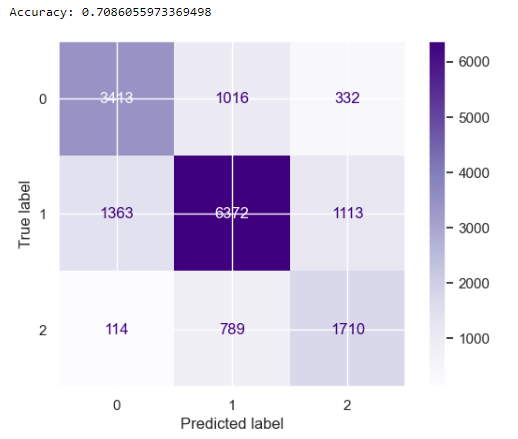

# Sieci neuronowe - dla mniej przetworzonych danych

Sieć neuronowa z jedną warstwą ukrytą

```python
mlp = MLPClassifier(hidden_layer_sizes=(2), max_iter=10000)
mlp.fit(train_inputs, train_classes)

from sklearn.metrics import accuracy_score

predictions_test = mlp.predict(test_inputs)
print(accuracy_score(predictions_test, test_classes))

confusion_matrix = metrics.confusion_matrix(test_classes,predictions_test)
cm_display = metrics.ConfusionMatrixDisplay(confusion_matrix = confusion_matrix)
cm_display = cm_display.plot(cmap=plt.cm.Oranges,values_format='g')
```

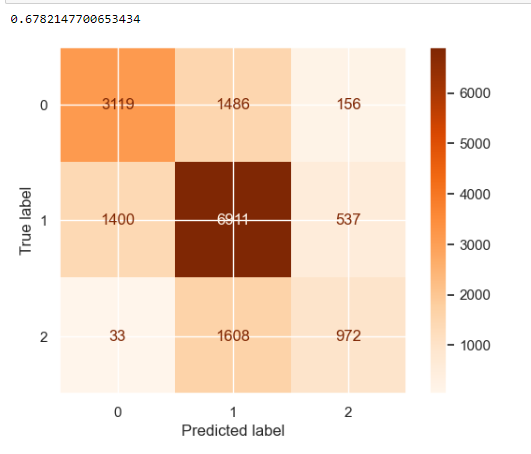

Sieć neuronowa z funkcją aktywacji Tanh

```python
model = Sequential()
model.add(Dense(17, activation='tanh'))
model.add(Dense(14,activation = 'tanh'))
model.add(Dense(11,activation = 'tanh'))
model.add(Dense(8,activation = 'tanh'))
model.add(Dense(5,activation = 'tanh'))
model.add(Dense(3,activation = 'tanh'))
model.add(Dense(1, activation = 'sigmoid'))

sgd = SGD(learning_rate = 0.001, momentum = 0.8)
model.compile(optimizer = sgd, loss = 'binary_crossentropy')

model.fit(train_inputs, train_classes,epochs = 100)

predictions = model.predict(test_inputs)
print('Accuracy:', accuracy_score(np.round(abs(predictions)),test_classes))

confusion_matrix = metrics.confusion_matrix(test_classes,np.round(abs(predictions)))
cm_display = metrics.ConfusionMatrixDisplay(confusion_matrix = confusion_matrix)
cm_display = cm_display.plot(cmap=plt.cm.Oranges,values_format='g')
```

Macierz błędów i dokładność:

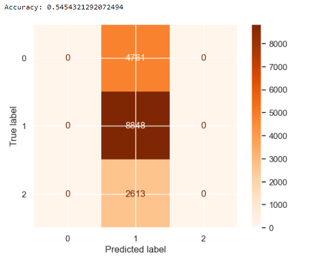

Krzywa uwzględniająca zb. trenujący i valid.

[figure not shown]

Sieć neuronowa z funkcją aktywacji Softmax, alg. optymalizacji Adam

```python
model = Sequential()
model.add(Dense(17, activation='softmax'))
model.add(Dense(14,activation = 'softmax'))
model.add(Dense(11,activation = 'softmax'))
model.add(Dense(8,activation = 'softmax'))
model.add(Dense(5,activation = 'softmax'))
model.add(Dense(3,activation = 'softmax'))
model.add(Dense(1, activation = 'sigmoid'))

model.compile(optimizer='adam', loss = 'binary_crossentropy')

model.fit(train_inputs, train_classes,epochs = 100)

predictions = model.predict(test_inputs)
print('Accuracy:', accuracy_score(np.round(abs(predictions)),test_classes))

confusion_matrix = metrics.confusion_matrix(test_classes,np.round(abs(predictions)))
cm_display = metrics.ConfusionMatrixDisplay(confusion_matrix = confusion_matrix)
cm_display = cm_display.plot(cmap=plt.cm.Oranges,values_format='g')
```

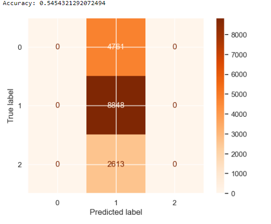

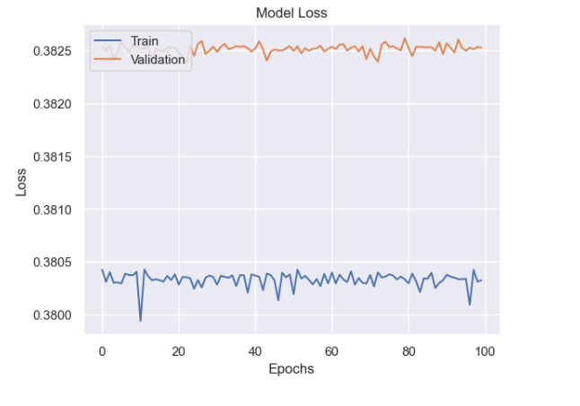

# Sieci neuronowe - dla bardziej przetworzonych danych

Sieć neuronowa z jedną warstwą ukrytą

```python
mlp = MLPClassifier(hidden_layer_sizes=(2), max_iter=10000)
mlp.fit(train_inputs1, train_classes1)

from sklearn.metrics import accuracy_score

predictions_test1 = mlp.predict(test_inputs1)
print(accuracy_score(predictions_test1, test_classes1))

confusion_matrix = metrics.confusion_matrix(test_classes1,predictions_test1)
cm_display = metrics.ConfusionMatrixDisplay(confusion_matrix = confusion_matrix)
cm_display = cm_display.plot(cmap=plt.cm.Oranges,values_format='g')
```

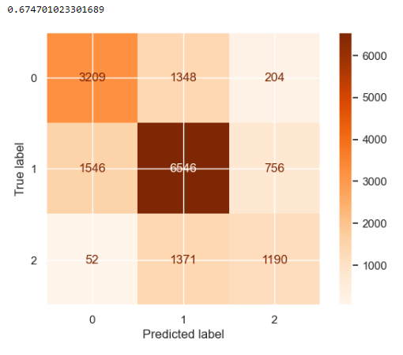

Sieć neuronowa z funkcją aktywacji Tanh

```python
model = Sequential()
model.add(Dense(12, activation='tanh'))
model.add(Dense(10,activation = 'tanh'))
model.add(Dense(8,activation = 'tanh'))
model.add(Dense(6,activation = 'tanh'))
model.add(Dense(4,activation = 'tanh'))
model.add(Dense(2,activation = 'tanh'))
model.add(Dense(1, activation = 'sigmoid'))

sgd = SGD(learning_rate = 0.001, momentum = 0.8)
model.compile(optimizer = sgd, loss = 'binary_crossentropy')

model.fit(train_inputs1, train_classes1,epochs = 100)

predictions = model.predict(test_inputs1)
print('Accuracy:', accuracy_score(np.round(abs(predictions)),test_classes1))

confusion_matrix = metrics.confusion_matrix(test_classes1,np.round(abs(predictions)))
cm_display = metrics.ConfusionMatrixDisplay(confusion_matrix = confusion_matrix)
cm_display = cm_display.plot(cmap=plt.cm.Oranges,values_format='g')
```

Dokładność i macierz błędów:

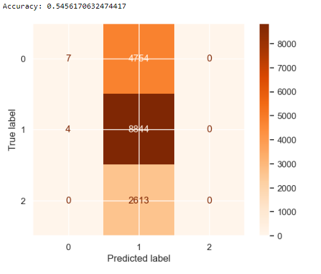

Krzywa uczenia się:

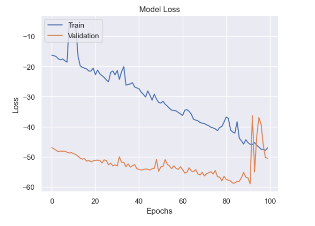

Sieć neuronowa z funkcją aktywacji Softmax, alg. optymalizacji Adam

```python
model = Sequential()
model.add(Dense(12, activation='softmax'))
model.add(Dense(10,activation = 'softmax'))
model.add(Dense(8,activation = 'softmax'))
model.add(Dense(6,activation = 'softmax'))
model.add(Dense(4,activation = 'softmax'))
model.add(Dense(2,activation = 'softmax'))
model.add(Dense(1, activation = 'sigmoid'))

model.compile(optimizer='adam', loss = 'binary_crossentropy')

model.fit(train_inputs1, train_classes1,epochs = 100)

predictions = model.predict(test_inputs1)
print('Accuracy:', accuracy_score(np.round(abs(predictions)),test_classes1))

confusion_matrix = metrics.confusion_matrix(test_classes1,np.round(abs(predictions)))
cm_display = metrics.ConfusionMatrixDisplay(confusion_matrix = confusion_matrix)
cm_display = cm_display.plot(cmap=plt.cm.Oranges,values_format='g')
```

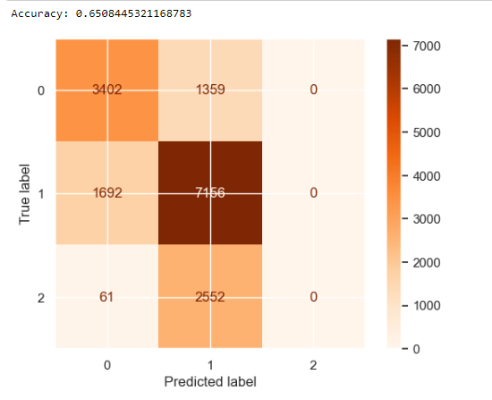

Krzywa uczenia się

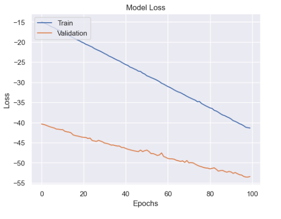